# Regression and model validation

*In this exercise, linear regression analysis is used to find out significant predictors of exam points of a statistics course exam.*

## Data

The data used in the analysis contains 166 cases and 7 variables. Variables “deep”, “stra”, and “surf” are combined variables indicating respondent’s learning strategies: deep, strategic and surface learning. “Attitude” indicates global attitude towards statistics, and “Points” indicates respondent’s exam points. In addition, age and gender are used as basic sociodemographic variables. Descriptive statistics of the data are displayed on the table above. There are considerably more females on the data: 110 vs. 56 males. As for learning strategies, the respondents tend to have slightly higher overall score on deep learning than other strategies.

```r
summary(analysis_data)
```

```
##  gender       Age           Attitude          deep            stra
##  F:110   Min.   :17.00   Min.   :1.400   Min.   :1.583   Min.   :1.250
##  M: 56   1st Qu.:21.00   1st Qu.:2.600   1st Qu.:3.333   1st Qu.:2.625
##          Median :22.00   Median :3.200   Median :3.667   Median :3.188
##          Mean   :25.51   Mean   :3.143   Mean   :3.680   Mean   :3.121
##          3rd Qu.:27.00   3rd Qu.:3.700   3rd Qu.:4.083   3rd Qu.:3.625
##          Max.   :55.00   Max.   :5.000   Max.   :4.917   Max.   :5.000
##       surf           Points
##  Min.   :1.583   Min.   : 7.00
##  1st Qu.:2.417   1st Qu.:19.00
##  Median :2.833   Median :23.00
##  Mean   :2.787   Mean   :22.72
##  3rd Qu.:3.167   3rd Qu.:27.75
##  Max.   :4.333   Max.   :33.00
```

The plot below demonstrates the distributions of the variables and the relationships between them on males (blue) and females (red). As for exam points, attitude has the strongest correlation. Overall, there are minor differences on the distributions and relationships between genders but nothing outstanding.

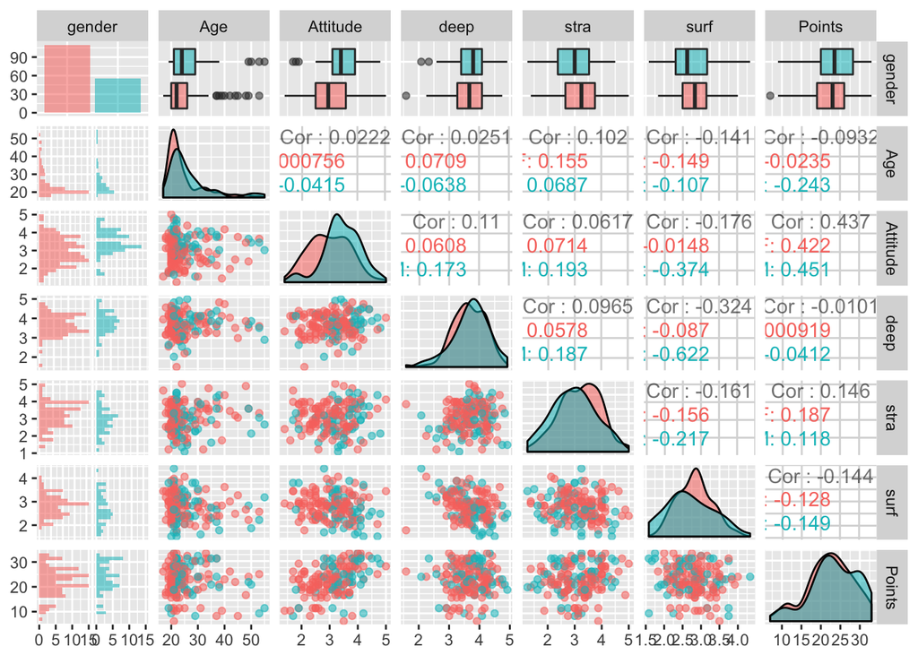

```r
p <- ggpairs(analysis_data, mapping = aes(col= gender, alpha = 0.3),
lower = list(combo = wrap("facethist", bins = 20)))
```

## Initial regression model

Initially, linear regression model is built with three explanatory variables: attitude, age and deep learning. The results of the analysis are displayed on the matrix below. Regarding the explanatory variables, only attitude is statistically significant (p<0.001) with beta-value of 3.59 indicating that increase of one unit of attitude increases the exam points by 3.59 in the model.

```r
my_model1 <- lm(Points ~ Attitude + Age + deep, data = analysis_data)

summary(my_model1)
```

```
##
## Call:
## lm(formula = Points ~ Attitude + Age + deep, data = analysis_data)
##
## Residuals:
##     Min      1Q  Median      3Q     Max
## -17.206  -3.430   0.204   3.979  10.950
##
## Coefficients:
##             Estimate Std. Error t value Pr(>|t|)
## (Intercept) 15.60773    3.38966   4.605 8.32e-06 ***
## Attitude     3.59413    0.56959   6.310 2.56e-09 ***
## Age         -0.07716    0.05322  -1.450    0.149
## deep        -0.60275    0.75031  -0.803    0.423
## ---
## Signif. codes:  0 '***' 0.001 '**' 0.01 '*' 0.05 '.' 0.1 ' ' 1
##
## Residual standard error: 5.307 on 162 degrees of freedom
## Multiple R-squared:  0.2043, Adjusted R-squared:  0.1896
## F-statistic: 13.87 on 3 and 162 DF,  p-value: 4.305e-08
```

## Fitted regression model

In the fitted linear regression model, age and deep learning are removed from the analysis as non-significant. In this model, attitude remains statistically significant (p<0.001) beta-value being 3.52. The r-square value of 0.19 indicates that the model explains about 19 % of the variability of the dependent “points” variable.

```r
my_model2 <- lm(Points ~ Attitude, data = analysis_data)
summary(my_model2)
```

```
##
## Call:
## lm(formula = Points ~ Attitude, data = analysis_data)
##
## Residuals:
##      Min       1Q   Median       3Q      Max
## -16.9763  -3.2119   0.4339   4.1534  10.6645
##
## Coefficients:
##             Estimate Std. Error t value Pr(>|t|)
## (Intercept)  11.6372     1.8303   6.358 1.95e-09 ***
## Attitude      3.5255     0.5674   6.214 4.12e-09 ***
## ---
## Signif. codes:  0 '***' 0.001 '**' 0.01 '*' 0.05 '.' 0.1 ' ' 1
##
## Residual standard error: 5.32 on 164 degrees of freedom
## Multiple R-squared:  0.1906, Adjusted R-squared:  0.1856
## F-statistic: 38.61 on 1 and 164 DF,  p-value: 4.119e-09
```

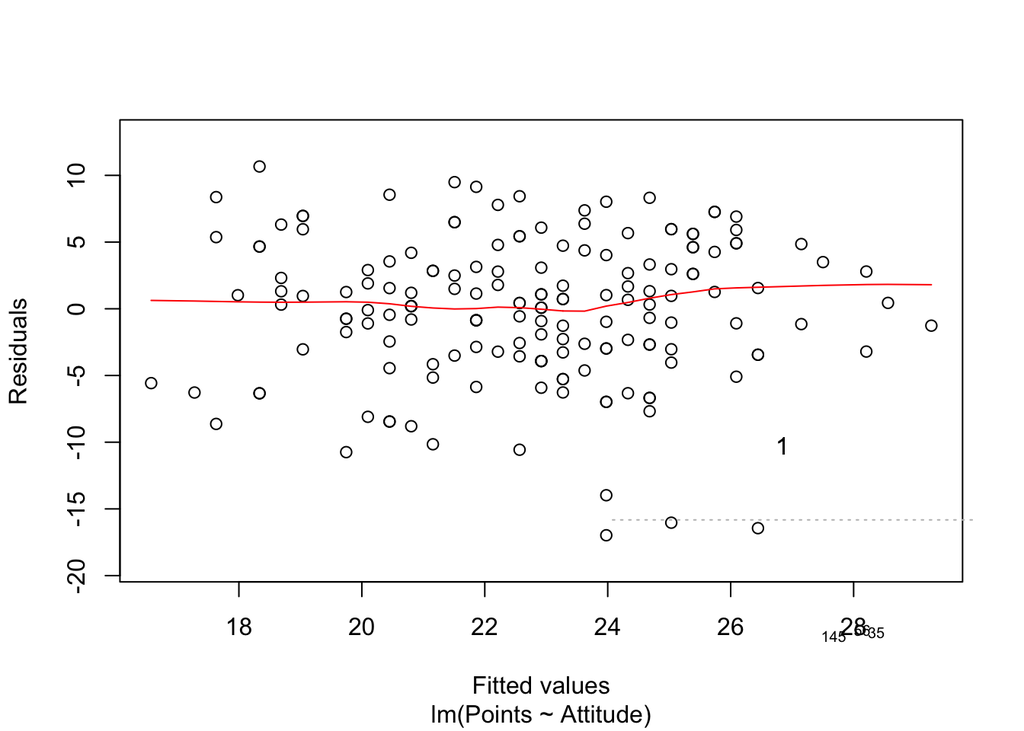

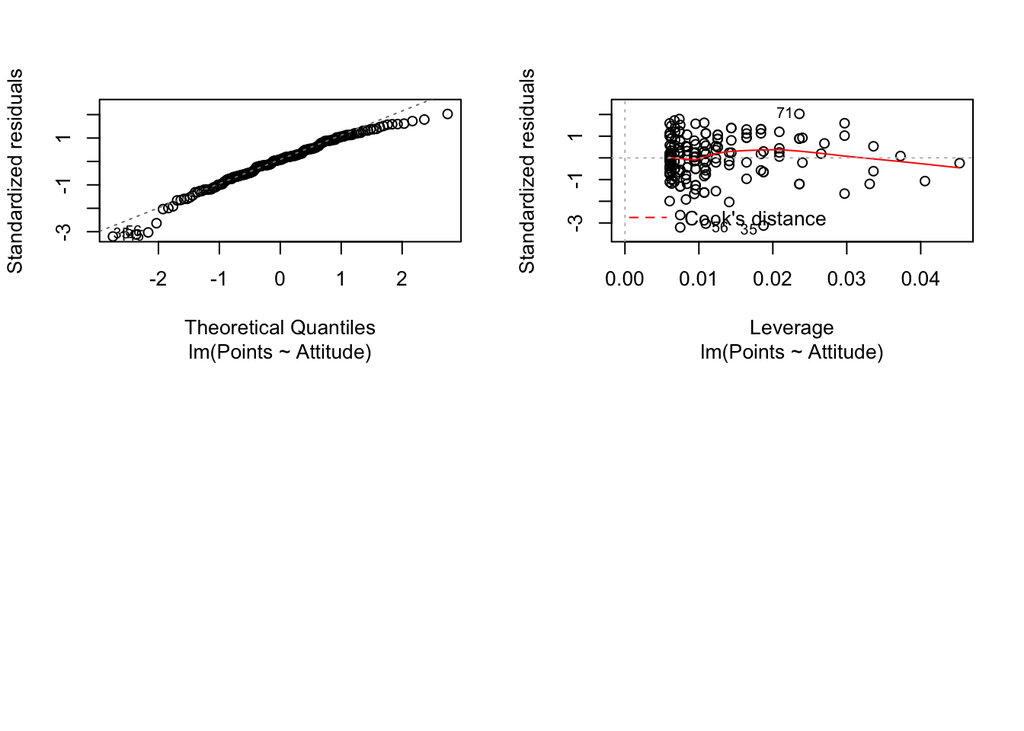

```r
plot(my_model2, which = c(1, 2, 5), par(mfrow = c(2,2)))
```